# AIML_ML_Project_full_code_notebook (1)

### Observation

- Performance on Trainset High accuracy indicates model is performing well on training set
- Precision > recall this suggest model is more conservative
- these high score suggest model is not underfitting
- About Test data performance precision > recall this model is conservative in predicting positive
- High accuracy and good f1 suggest model generalizes as well on the test data
- the model is neither overfitting or underfitting.

**Cost-complexity pruning**

```python
#compute the pruning path for the decison tree using minimal cost complexity pruning

clf=DecisionTreeClassifier(random_state=1)
path=clf.cost_complexity_pruning_path(x_train,y_train)
ccp_alphas, impurities=path.ccp_alphas, path.impurities

# create dataframe and sort by ccp_alphas by descending order
pruning_path_df=pd.DataFrame(path)

pruning_path_df_sorted=pruning_path_df.sort_values(by='ccp_alphas',ascending=False)
pruning_path_df_sorted
```

|  | ccp_alphas | impurities |
| --- | --- | --- |
| 22 | 0.056365 | 0.171255 |
| 21 | 0.023866 | 0.058525 |
| 20 | 0.006473 | 0.034659 |
| 19 | 0.003294 | 0.028187 |
| 18 | 0.003024 | 0.024893 |
| 17 | 0.002333 | 0.021869 |
| 16 | 0.001552 | 0.019536 |
| 15 | 0.000882 | 0.017985 |
| 14 | 0.000769 | 0.014456 |
| 13 | 0.000641 | 0.011379 |
| 12 | 0.000593 | 0.008813 |
| 11 | 0.000582 | 0.007628 |
| 10 | 0.000527 | 0.007046 |
| 9 | 0.000476 | 0.006519 |
| 6 | 0.000381 | 0.005280 |
| 8 | 0.000381 | 0.006042 |
| 7 | 0.000381 | 0.005661 |
| 5 | 0.000359 | 0.004900 |
| 4 | 0.000268 | 0.003824 |
| 3 | 0.000242 | 0.002750 |
| 2 | 0.000214 | 0.001542 |
| 1 | 0.000186 | 0.001114 |
| 0 | 0.000000 | 0.000000 |

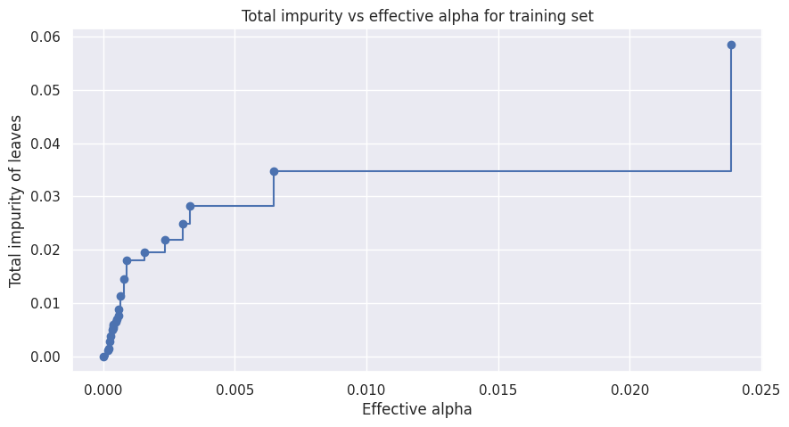

```python
# create a figure and an axis object with a specified size
fig,ax=plt.subplots(figsize=(10,5))
# plot the relationship between effective alpha and total impurity leaves
ax.plot(ccp_alphas[:-1],impurities[:-1],marker='o',drawstyle="steps-post")
# set the label for the X-axis
ax.set_xlabel("Effective alpha")
# set the label for the Y-axis
ax.set_ylabel("Total impurity of leaves")
# set the title of the plot
ax.set_title("Total impurity vs effective alpha for training set")

plt.show()
```

- Now, we train a decision tree using effective alphas,The last value in ccp_alphas is the alpha value that prunes the whole tree,leaving the tree, clfs[-1], with one node.

```python
# initialize an empty array list to store the decision tree classifier
clfs=[]
# loop through the effective ccp_alpha values
for ccp_alpha in ccp_alphas:
  # create a decision tree classifier with the current ccp_alpha value
  clf=DecisionTreeClassifier(random_state=1,ccp_alpha=ccp_alpha)
  # fit the classifier to the training data
  clf.fit(x_train,y_train)
  # append the classifier to the list
  clfs.append(clf)

#Print the no.of nodes in the last tree and correspomding ccp_alpha value
print("Number of nodes in the last tree is {} with ccp_alpha {}:".format(clfs[-1].tree_.node_count,ccp_alphas[-1]))
```

```
Number of nodes in the last tree is 1 with ccp_alpha 0.056364969335601575:
```

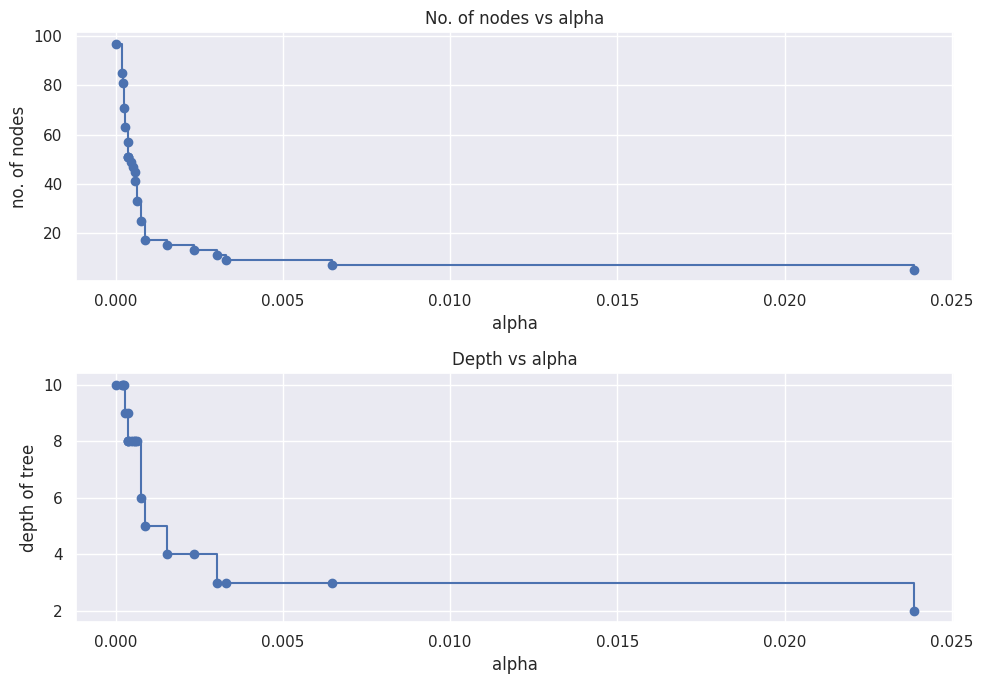

```python
#Remove the last element from list of classifier and ccp_alpha
clfs=clfs[:-1]
ccp_alphas=ccp_alphas[:-1]
#calculate the no.of nodes for each classifier
node_counts=[clf.tree_.node_count for clf in clfs]
#calculate the depth of each classifier
depths=[clf.tree_.max_depth for clf in clfs]
# create a figure with subplots arranged vertically, with specified size
fig, ax=plt.subplots(2,1,figsize=(10,7))

#plot the no of nodes Vs alpha on subplot
ax[0].plot(ccp_alphas,node_counts,marker='o',drawstyle="steps-post")
ax[0].set_xlabel("alpha")
ax[0].set_ylabel("no. of nodes")
ax[0].set_title("No. of nodes vs alpha")
#plt.show()

ax[1].plot(ccp_alphas,depths,marker='o',drawstyle="steps-post")
ax[1].set_xlabel("alpha")
ax[1].set_ylabel("depth of tree")
ax[1].set_title("Depth vs alpha")

fig.tight_layout()
```

**Recall Vs alpha for training and test sets**

```python
#initialize an empty list to stores recall scores for the training data
recall_train=[]
#Loop for the list of classification
for clf in clfs:
  #predict the labels for the training set using current classificastion
  train_pred=clf.predict(x_train)
  #calculate the recall score for the current classification
  recall=recall_score(y_train,train_pred)
  #append the recall score to the list
  recall_train.append(recall)

#initialize the empty list to store recall score forthe test set
recall_test=[]
#loop through the list of classification
for clf in clfs:
  #predict the labels for the test set using current classification
  test_pred=clf.predict(x_test)
  #calculate the recall score for the test
  value_test=recall_score(y_test,test_pred)
  #append the recall score to the list
  recall_test.append(value_test)
```

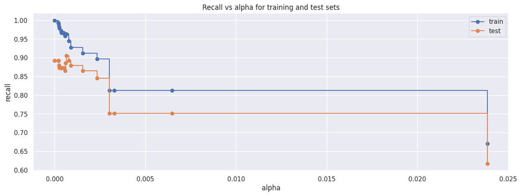

```python
#create a figure and an axis object with a specified size
fig,ax=plt.subplots(figsize=(15,5))
ax.set_xlabel("alpha")
ax.set_ylabel("recall")
ax.set_title("Recall vs alpha for training and test sets")
ax.plot(ccp_alphas,recall_train,marker='o',label="train",drawstyle="steps-post")
ax.plot(ccp_alphas,recall_test,marker='o',label="test",drawstyle="steps-post")
ax.legend()
plt.show()
```

```python
# find the index of classifier with highest recall score on test data
best_index_model=np.argmax(recall_test)
# select classifier corresponding to the best recall score
best_model=clfs[best_index_model]
print(best_model)
```

```
DecisionTreeClassifier(ccp_alpha=np.float64(0.0006414326414326415),
                       random_state=1)
```

**Post-Pruning**

**Checking the performance on training data**

```python
#initialize the decision tree classifier with the last ccp_alpha value from the pruning path
# set class weights to handle class imbalance, and set a random state for reproducibility

estimator_2=DecisionTreeClassifier(ccp_alpha=ccp_alphas[-1], #use last ccp_alpha value
                                   random_state=1,
                                   class_weight="balanced" )# set class weights)
#fit the model on training data
estimator_2.fit(x_train,y_train)
```

```
DecisionTreeClassifier(ccp_alpha=np.float64(0.02386594448205822),
                       class_weight='balanced', random_state=1)
```

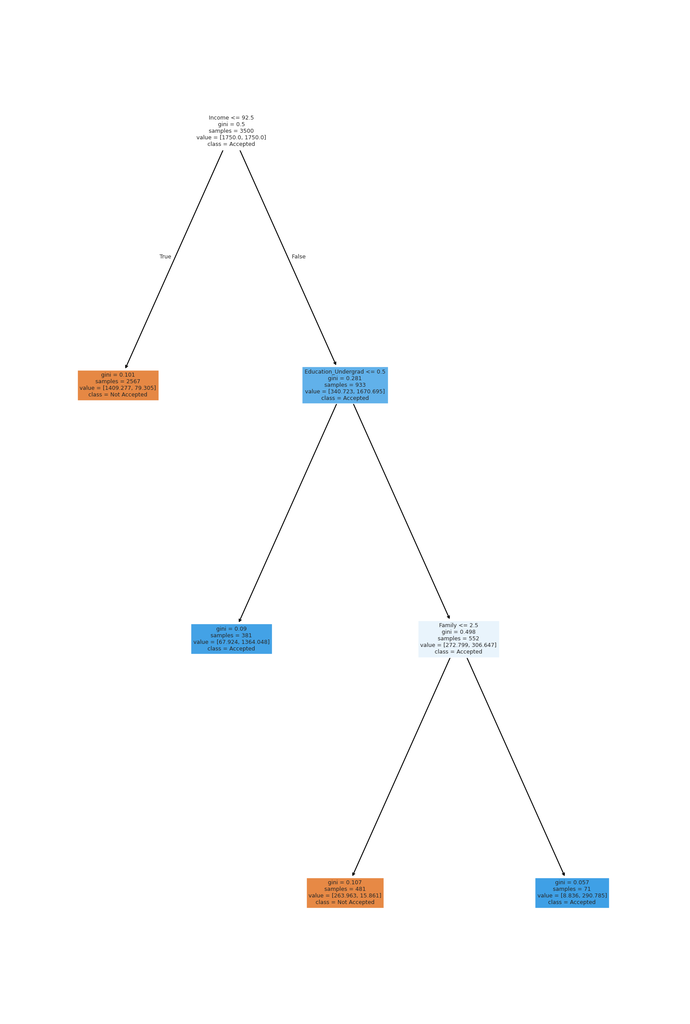

```python
# visualization the decision tree

plt.figure(figsize=(20,30))
out=tree.plot_tree(
                    estimator_2,
                   feature_names=feature_names_lst,
                    filled=True,
                  fontsize=9,
                  node_ids=False,
                  class_names=['Not Accepted','Accepted'])

#add arrows to decision tree split if they are missing
for o in out:
  arrow=o.arrow_patch
  if arrow is not None:
    arrow.set_edgecolor('black')
    arrow.set_linewidth(1.5)
plt.show()
```

```python
#Generate the text report showing the rules of the decision tree
print(tree.export_text(estimator_2,feature_names=feature_names_lst,show_weights=True))
```

```
|--- Income <= 92.50
|   |--- weights: [1409.28, 79.31] class: 0
|--- Income >  92.50
|   |--- Education_Undergrad <= 0.50
|   |   |--- weights: [67.92, 1364.05] class: 1
|   |--- Education_Undergrad >  0.50
|   |   |--- Family <= 2.50
|   |   |   |--- weights: [263.96, 15.86] class: 0
|   |   |--- Family >  2.50
|   |   |   |--- weights: [8.84, 290.79] class: 1
```

```python
# check the performance on test data
decision_tree_tune_post_test=model_performance_classification_sklearn(estimator_2,x_test,y_test)
decision_tree_tune_post_test
```

|  | Accuracy | Precision | Recall | F1_score |
| --- | --- | --- | --- | --- |
| 0 | 0.950667 | 0.690355 | 0.912752 | 0.786127 |

```python
#Assign the feature importance to a varibles
importances=estimator_2.feature_importances_
#sort the indices in descending order
indices=np.argsort(importances)[::1]

#create a Dataframe for feature importances
feature_importances_df=pd.DataFrame({'Feature':[feature_names_lst[i] for i in indices],
                                     'Importance':importances[indices]})

print(feature_importances_df)
```

```
                            Feature  Importance
0                               Age    0.000000
1                             CCAvg    0.000000
2                Securities_Account    0.000000
3                          Mortgage    0.000000
4                        CD_Account    0.000000
5                            Online    0.000000
6                        ZIPCode_90    0.000000
7                        CreditCard    0.000000
8                        ZIPCode_93    0.000000
9                        ZIPCode_94    0.000000
10                       ZIPCode_91    0.000000
11                       ZIPCode_92    0.000000
12                       ZIPCode_95    0.000000
13                       ZIPCode_96    0.000000
14  Education_Advanced/Professional    0.000000
15               Education_Graduate    0.000000
16              Education_Undergrad    0.103891
17                           Family    0.169781
18                           Income    0.726328
```

```python
#Check the performance on trianing data
decision_tree_tune_post_train=model_performance_classification_sklearn(estimator_2,x_train,y_train)
decision_tree_tune_post_train
```

|  | Accuracy | Precision | Recall | F1_score |
| --- | --- | --- | --- | --- |
| 0 | 0.955143 | 0.692478 | 0.945619 | 0.799489 |

### Observation

- Performance on Training set, recall is prioritize over precision
- The F1 score reflects the trade-off between precison and recall
- Performance on test set, High recall and low precision
- Model perform well on detecting actual positive, and it also tends to misclassify some negatives as positives

## Model Performance Comparison and Final Model Selection

```python
#Training data performance comparision
# concatenate the performances DataFrame along with the columns
model_train_comp_df=pd.concat([decision_tree_perf_train.T,
                               decision_tree_perf_train_1.T,
                               decision_tree_tune_train.T,
                               decision_tree_tune_post_train.T],axis=1)

#set the column name for concatenated DataFRame
model_train_comp_df.columns=['DecisionTree sklearn','Class_Weight','Pre-Pruning','Post-Pruning']
print("Training performace comparision")
model_train_comp_df
```

```
Training performace comparision
```

|  | DecisionTree sklearn | Class_Weight | Pre-Pruning | Post-Pruning |
| --- | --- | --- | --- | --- |
| Accuracy | 1.0 | 1.0 | 0.987714 | 0.955143 |
| Precision | 1.0 | 1.0 | 0.952830 | 0.692478 |
| Recall | 1.0 | 1.0 | 0.915408 | 0.945619 |
| F1_score | 1.0 | 1.0 | 0.933744 | 0.799489 |

```python
#Test data performance comparision
# concatenate the performances DataFRame along with the columns
model_test_comp_df=pd.concat([decision_tree_perf_test.T,
                              decision_tree_perf_test_1.T,
                              decision_tree_tune_test.T,
                              decision_tree_tune_post_test.T],axis=1)

#set the column name for concatenated DataFRame
model_test_comp_df.columns=['DecisionTree sklearn','Class_Weight','Pre-Pruning','Post-Pruning']
print("Test performace comparision")
model_test_comp_df
```

```
Test performace comparision
```

|  | DecisionTree sklearn | Class_Weight | Pre-Pruning | Post-Pruning |
| --- | --- | --- | --- | --- |
| Accuracy | 0.979333 | 0.973333 | 0.979333 | 0.950667 |
| Precision | 0.898649 | 0.875862 | 0.933824 | 0.690355 |
| Recall | 0.892617 | 0.852349 | 0.852349 | 0.912752 |
| F1_score | 0.895623 | 0.863946 | 0.891228 | 0.786127 |

## Actionable Insights and Business Recommendations

### Recommendation- Choose **Pre-pruning**

**What recommedations would you suggest to the bank?**

1. **Data Overall**:
   - Collect additional data to better understand why loans are not being accepted. Example, are people not accepting loans because they have defaulted with other banks?
   - Collect satisfaction data for various services, eg. Online Banking, CD and Securities accounts, CC accounts.
   - Collect payment data to see if customers are missing payments which would determine if offers are made to specific customers or an entire demographic.
   - Collect loyalty time. How long has a customer been a member of the bank?
1. **Loyalty**:
   - Create a loyalty program with better rates and service fees.
2. **Customer Segmentation**:
   - Review the different ZIP codes and possibly offer targeted campaigns or special programs for higher value services (loans, CCs, etc.). These personal loans could be larger amounts than those on the lower end of income.
   - Review customer accounts for those on the lower end and determine if offering lower loan amounts with reduced rates could bolster this demographic to accept personal loans.
3. **Business Processes**:
   - Use the model to automate parts of the personal loan approval process. By doing this it would reduce the time and effort required to make an offer and manual reviews of applicants. This can lead to faster loan processing and improved customer satisfaction.
   - As part of automation implement stricter credit checks or offer smaller loan amounts to customers to mitigate risk. Analysis of income and average CC information can be used to make determinations.
   - Actively monitor the performance of the model. As new data is available ensure to update the model periodically to ensure it remains accurate and relevant.